# Task 2: Microbiome Analysis and Protein Structure Prediction

# Statistics

## Alpha diversity

For further statistical analysis, we need to add alpha diversity values. First, we add the alpha diversity values and display them:

```r
index <- c("coverage", "inverse_simpson", "gini", "shannon_diversity")
tse <- addAlpha(tse, index = index)

cat("Alpha diversity indices added to the object:\n")
```

```
## Alpha diversity indices added to the object:
```

```r
print(colnames(colData(tse)))
```

```
##  [1] "ID"                "TypeofSample"      "Genotype"
##  [4] "Environment"       "Forward"           "Reverse"
##  [7] "coverage"          "inverse_simpson"   "gini"
## [10] "shannon_diversity"
```

Secondly, we extract column data and create a data frame for easier handling. To verify, we display the column headers:

```r
col_dat <- as.data.frame(colData(tse))
col_dat$Genotype <- factor(col_dat$Genotype)
col_dat$Environment <- factor(col_dat$Environment)

diversity_data <- as.data.frame(col_dat)

cat("Diversity data structure:\n")
```

```
## Diversity data structure:
```

```r
available_cols <- intersect(c("ID", "Genotype", "Environment",
                              "shannon_diversity", "coverage",
                              "inverse_simpson", "gini"),
                           colnames(diversity_data))
print(head(diversity_data[, available_cols]))
```

```
##        ID Genotype Environment shannon_diversity coverage inverse_simpson
## AN10 AN10    AIMS4     Sterile          2.818336       19        9.511588
## AN22 AN22    AIMS1     Sterile          3.304708       30       14.542468
## AN27 AN27    AIMS4     Sterile          3.672136       40       24.988314
## AN40 AN40    AIMS4     Sterile          3.310605       27       17.245555
## AN45 AN45    AIMS1     Sterile          3.335602       33       14.431951
## AN48 AN48    AIMS4     Sterile          2.990787       20       13.144840
##           gini
## AN10 0.9757104
## AN22 0.9601692
## AN27 0.9458373
## AN40 0.9623399
## AN45 0.9580389
## AN48 0.9726627
```

```r
# Summary statistics
cat("\n\nSummary statistics for diversity measures:\n")
```

```
##
##
## Summary statistics for diversity measures:
```

```r
print(summary(diversity_data[, available_cols[-1: -6]]))
```

```
##    Min. 1st Qu.  Median    Mean 3rd Qu.    Max.
##  0.8923  0.9245  0.9458  0.9463  0.9726  0.9807
```

Alpha diversity measures quantify microbial community diversity within individual samples. Different indices emphasize different aspects:

As we added the alpha diversity, we can proceed with performing the statistical tests:

## Statistical Testing

### Genotype significance

First, we want to have a look at the genotype:

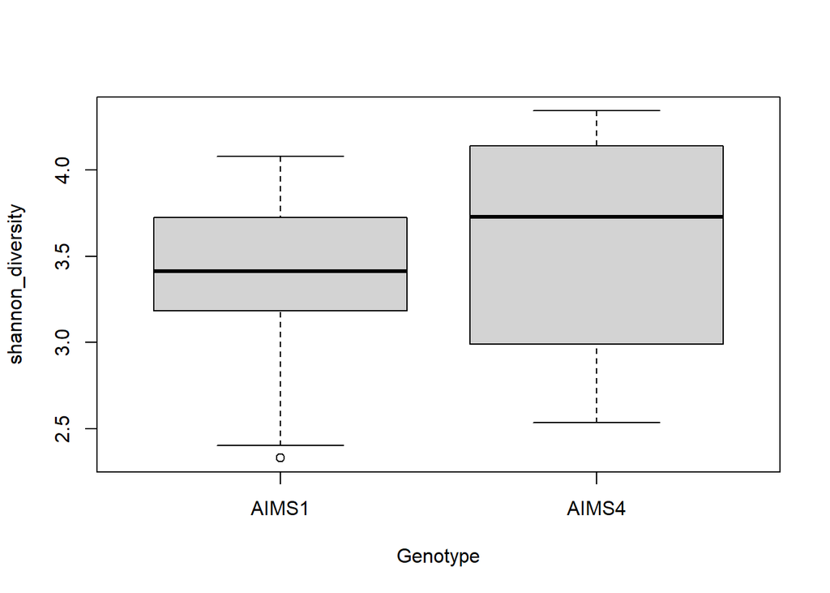

```r
p_shannon_genotype <- plotColData(tse, "shannon_diversity", "Genotype",
                                   colour_by = "Environment", show_median = TRUE) +
  labs(x = "Genotype",
       title = "Shannon Diversity by Genotype")

plot(shannon_diversity ~ Genotype, col_dat)
```

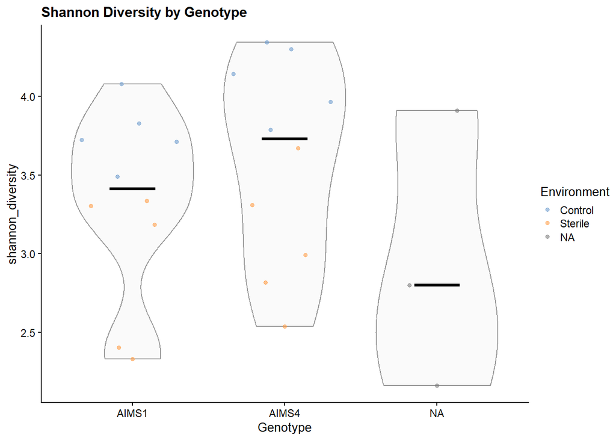

```r
#If needed, we can save it:
#ggsave("figures/Shannon_div_Genty.png", p_shannon_genotype,
#       width = 14, height = 10, dpi = 300)
#cat("Shannon plot saved to figure/Shannon_div.png\n")

print(p_shannon_genotype)
```

```r
t.test(shannon_diversity ~ Genotype, col_dat)
```

```
##
##  Welch Two Sample t-test
##
## data:  shannon_diversity by Genotype
## t = -0.90764, df = 17.81, p-value = 0.3762
## alternative hypothesis: true difference in means between group AIMS1 and group AIMS4 is not equal to 0
## 95 percent confidence interval:
##  -0.8227698  0.3265980
## sample estimates:
## mean in group AIMS1 mean in group AIMS4
##            3.338834            3.586919
```

For the means of this course, we tried to deepen the analysis a bit:

```r
# Student's t-test for genotype
diversity_measures <- c("shannon_diversity", "faith_diversity", "coverage",
                        "inverse_simpson", "gini")
ttest_genotype_shannon <- t.test(shannon_diversity ~ Genotype, col_dat)
print(ttest_genotype_shannon)
```

```
##
##  Welch Two Sample t-test
##
## data:  shannon_diversity by Genotype
## t = -0.90764, df = 17.81, p-value = 0.3762
## alternative hypothesis: true difference in means between group AIMS1 and group AIMS4 is not equal to 0
## 95 percent confidence interval:
##  -0.8227698  0.3265980
## sample estimates:
## mean in group AIMS1 mean in group AIMS4
##            3.338834            3.586919
```

```r
# Store results
gen_results <- list()
gen_pvalues <- numeric(length(diversity_measures))
gen_means <- data.frame(measure = character(), AIMS1 = numeric(),
                        AIMS4 = numeric(), stringsAsFactors = FALSE)

names(gen_pvalues) <- diversity_measures


cat("\nEffect size:\n")
```

```
##
## Effect size:
```

```r
aims1_mean <- mean(col_dat[col_dat$Genotype == "AIMS1", "shannon_diversity"], na.rm = TRUE)
aims4_mean <- mean(col_dat[col_dat$Genotype == "AIMS4", "shannon_diversity"], na.rm = TRUE)
cat("AIMS1 mean Shannon diversity:", round(aims1_mean, 3), "\n")
```

```
## AIMS1 mean Shannon diversity: 3.339
```

```r
cat("AIMS4 mean Shannon diversity:", round(aims4_mean, 3), "\n")
```

```
## AIMS4 mean Shannon diversity: 3.587
```

```r
cat("Difference:", round(abs(aims1_mean - aims4_mean), 3), "\n")
```

```
## Difference: 0.248
```

### Environmental significance

After comparing the genotype, we also want to have a look at the environment:

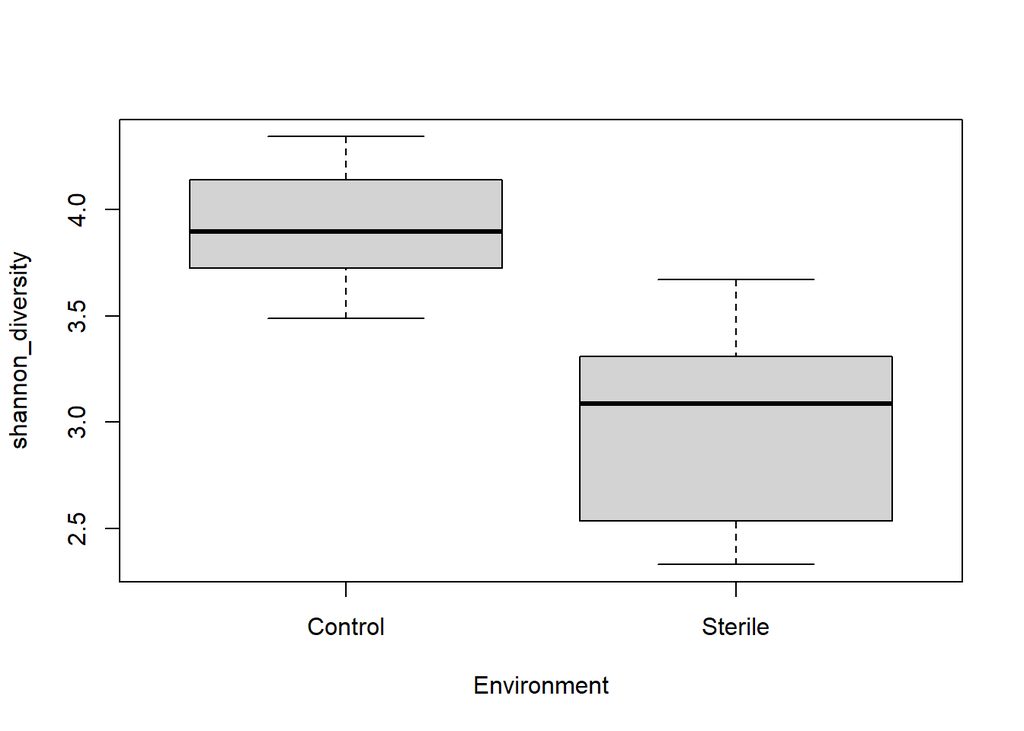

```r
p_shannon_environment <- plotColData(tse, "shannon_diversity", "Environment",
                                      colour_by = "Genotype", show_median = TRUE) +
  labs(x = "Environment",
       title = "Shannon Diversity by Environment")

plot(shannon_diversity ~ Environment, col_dat)
```

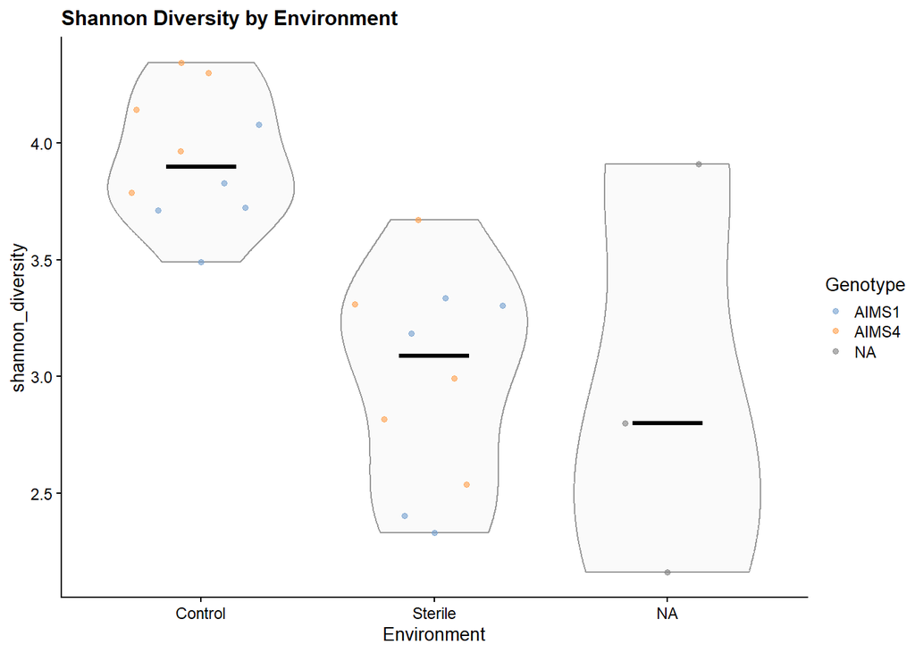

```r
#If needed, we can save it:
#ggsave("figures/Shannon_div_Env.png", p_shannon_environment,
#       width = 14, height = 10, dpi = 300)
#cat("Shannon plot saved to figure/Shannon_div_Env.png\n")

print(p_shannon_environment)
```

```r
# Student's t-test for genotype
ttest_environment_shannon <- t.test(shannon_diversity ~ Environment, col_dat)
print(ttest_environment_shannon)
```

```
##
##  Welch Two Sample t-test
##
## data:  shannon_diversity by Environment
## t = 5.6581, df = 14.929, p-value = 4.63e-05
## alternative hypothesis: true difference in means between group Control and group Sterile is not equal to 0
## 95 percent confidence interval:
##  0.5912145 1.3063373
## sample estimates:
## mean in group Control mean in group Sterile
##              3.937264              2.988489
```

```r
# Store results
env_results <- list()
env_pvalues <- numeric(length(diversity_measures))
env_means <- data.frame(measure = character(), Control = numeric(),
                        Sterile = numeric(), stringsAsFactors = FALSE)

names(env_pvalues) <- diversity_measures

cat("\nEffect size:\n")
```

```
##
## Effect size:
```

```r
aims1_mean <- mean(col_dat[col_dat$Genotype == "AIMS1", "shannon_diversity"], na.rm = TRUE)
aims4_mean <- mean(col_dat[col_dat$Genotype == "AIMS4", "shannon_diversity"], na.rm = TRUE)
cat("AIMS1 mean Shannon diversity:", round(aims1_mean, 3), "\n")
```

```
## AIMS1 mean Shannon diversity: 3.339
```

```r
cat("AIMS4 mean Shannon diversity:", round(aims4_mean, 3), "\n")
```

```
## AIMS4 mean Shannon diversity: 3.587
```